# Telco Customer Churn

Dataset sourced from: https://www.kaggle.com/blastchar/telco-customer-churn

This dataset contains details about the telecom company, Telco's customers where each row represents one customer. My aim is to predict whether the customer will leave or not, while also trying to unearth patterns in what type of customers tend to churn.

### Features:

**gender:** M or F  
**SeniorCitizen:** Whether customer is senior citizen or not  
**Partner :** Whether customer has a partner or not  
**Dependents :** Whether customer has dependents or not  
**tenure :** How long the customer was with the company, in months  
**PhoneService :** Whether customer has phone line or not  
**MultipleLines :** Whether customer has multiple phone lines or not  
**InternetService :** Type of internet service provided: DSL, FIber or no internet  
**OnlineSecurity :** Whethere customer has availed this additonal service  
**OnlineBackup :** Whethere customer has availed this additonal service  
**DeviceProtection :** Whethere customer has availed this additonal service  
**TechSupport :** Whethere customer has availed this additonal service  
**StreamingTV :** Whethere customer has availed this additonal service  
**StreamingMovies :** Whethere customer has availed this additonal service  
**Contract :** Whether customer's contract is month to month or yearly  
**PaperlessBilling :** Yes or No  
**PaymentMethod :** Method of payment used by customer  
**MonthlyCharges :** Charges in dollars  
**TotalCharges :** Total charges(monhtly * tenure)  
**Churn :** Yes or No

Please use **Show/Hide Code** button below to see the code

```python
from IPython.display import HTML

HTML('''<script>
code_show=true;
function code_toggle() {
 if (code_show){
 $('div.input').hide();
 } else {
 $('div.input').show();
 }
 code_show = !code_show
}
$( document ).ready(code_toggle);
</script>
<form action="javascript:code_toggle()"><input type="submit" value="Show/Hide Code"></form>''')
```

```python
#all the import statements

import pandas as pd
import numpy as np
import seaborn as sns
import matplotlib.pyplot as plt
%matplotlib inline
```

```python
#read data

data = pd.read_csv('telco_churn.csv')
```

## Take a look at the data

```python
data.head()
```

|  | customerID | gender | SeniorCitizen | Partner | Dependents | tenure | PhoneService | MultipleLines | InternetService | OnlineSecurity | ... | DeviceProtection | TechSupport | StreamingTV | StreamingMovies | Contract | PaperlessBilling | PaymentMethod | MonthlyCharges | TotalCharges | Churn |
| --- | --- | --- | --- | --- | --- | --- | --- | --- | --- | --- | --- | --- | --- | --- | --- | --- | --- | --- | --- | --- | --- |
| 0 | 7590-VHVEG | Female | 0 | Yes | No | 1 | No | No phone service | DSL | No | ... | No | No | No | No | Month-to-month | Yes | Electronic check | 29.85 | 29.85 | No |
| 1 | 5575-GNVDE | Male | 0 | No | No | 34 | Yes | No | DSL | Yes | ... | Yes | No | No | No | One year | No | Mailed check | 56.95 | 1889.5 | No |
| 2 | 3668-QPYBK | Male | 0 | No | No | 2 | Yes | No | DSL | Yes | ... | No | No | No | No | Month-to-month | Yes | Mailed check | 53.85 | 108.15 | Yes |
| 3 | 7795-CFOCW | Male | 0 | No | No | 45 | No | No phone service | DSL | Yes | ... | Yes | Yes | No | No | One year | No | Bank transfer (automatic) | 42.30 | 1840.75 | No |
| 4 | 9237-HQITU | Female | 0 | No | No | 2 | Yes | No | Fiber optic | No | ... | No | No | No | No | Month-to-month | Yes | Electronic check | 70.70 | 151.65 | Yes |

5 rows × 21 columns

**Obsrvations:** There are some missing values in Total charges which has been replaced by 0

```python
data['TotalCharges'] = data['TotalCharges'].replace(" ", 0).astype('float32')
```

## Percentage of Churn

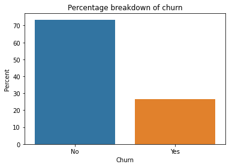

```python
ax = sns.barplot(x="Churn", y="TotalCharges", data=data, estimator=lambda x: len(x) / len(data) * 100)
ax.set(ylabel="Percent")
ax.set_title('Percentage breakdown of churn')
```

**Obsrvations:** A quarter of the customers has churned

## How Tenure and gender affects churn

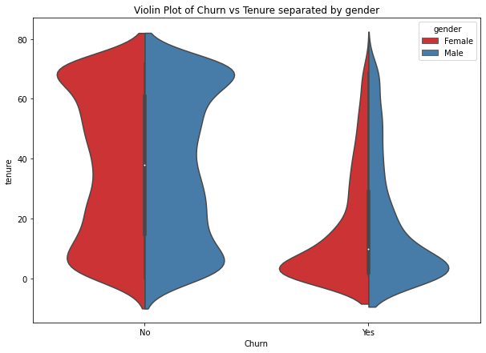

```python
fig_dims = (10, 7)
fig, ax = plt.subplots(figsize=fig_dims)
ax.set_title('Violin Plot of Churn vs Tenure separated by gender')
sns.violinplot(x="Churn", y="tenure", data=data, hue='gender', split=True, palette='Set1')
```

**Obsrvations:**

1. We can see that gender does not really have an effect on whether customer will churn or not. Telco does not dsicriminate!
2. New customers tend to churn more compared to long term customers. We can see the 'Yes' violin plot steeply reduce as tenure increases

## How having dependents or partners affect churn along with monthly charges

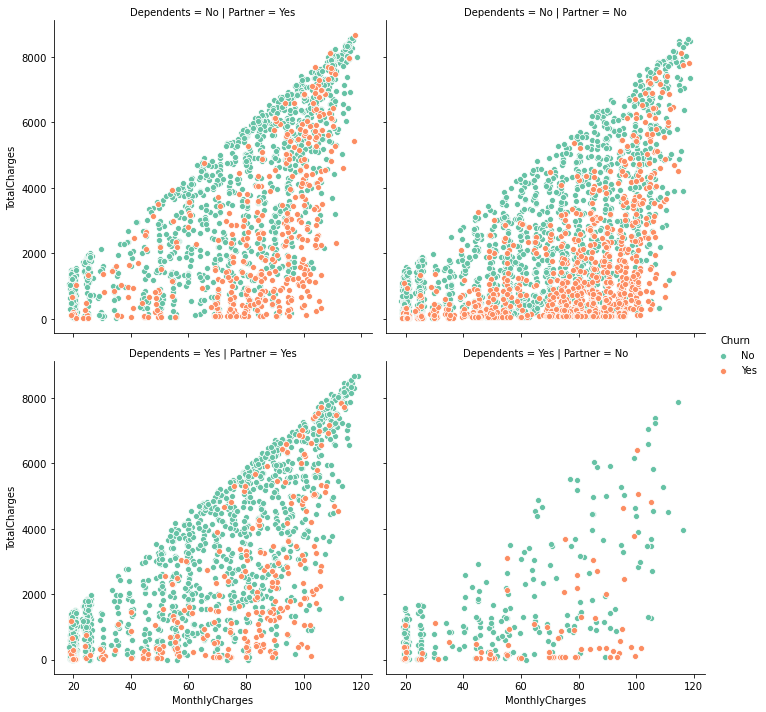

```python
g = sns.FacetGrid(data, col="Partner",  row="Dependents",hue='Churn', palette='Set2', height=5, aspect=1)
g = g.map(sns.scatterplot, "MonthlyCharges", "TotalCharges").add_legend()
```

**Obsrvations:**

1. Higher monthly charges seem to be a reason a lot of customers are churning
2. Customer with no dependents or partners tend to churn a lot
3. Inversely customers with dependents and partners tend to be the most loyal

## Percentage of churn among customers with no dependents or partners

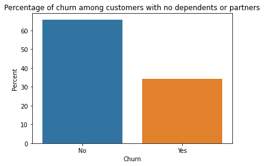

```python
ax = sns.barplot(x="Churn", y="TotalCharges", data=data[(data['Dependents']=='No') & (data['Partner']=='No')],
                 estimator=lambda x: len(x) / len(data[(data['Dependents']=='No') & (data['Partner']=='No')]) * 100)
ax.set(ylabel="Percent")
ax.set_title('Percentage of churn among customers with no dependents or partners')
```

**Obsrvations:** As we can see around a 3rd of customers with no dependents or partners has churned. Maybe they should be given better offers or services

## Breakdown of Churn among customer with multiple phone lines and type of Internet Service

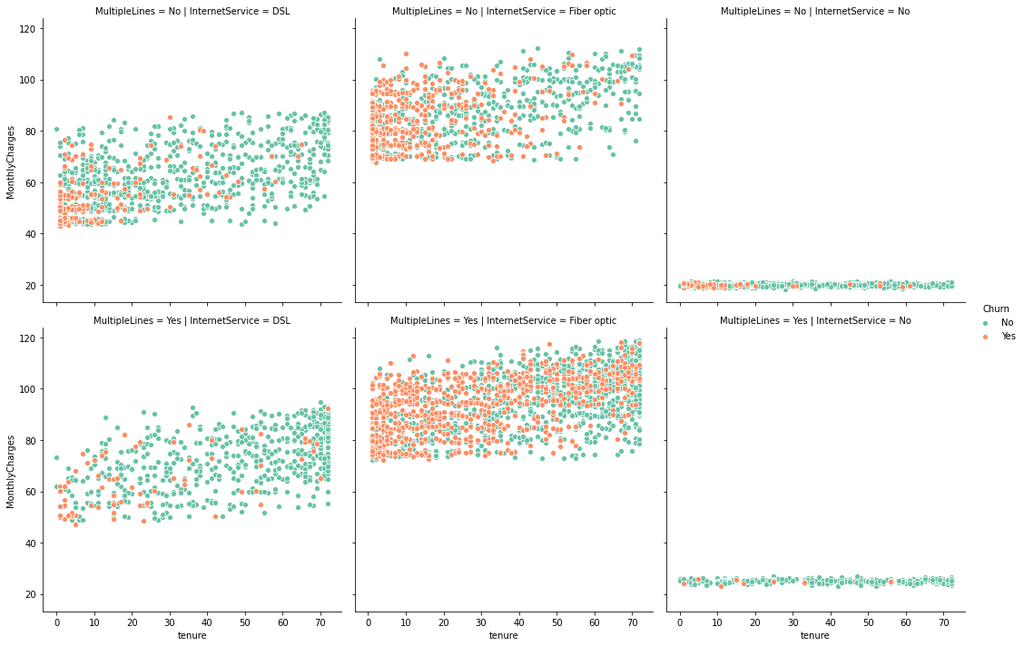

```python
g = sns.FacetGrid(data[data['PhoneService']=='Yes'], col="InternetService",  row="MultipleLines", hue='Churn',
                  palette='Set2', height=5, aspect=1)
g = g.map(sns.scatterplot, "tenure", "MonthlyCharges").add_legend()
```

**Obsrvations:** We can see that a lot of customers with fiber optic connection has churned a lot. Lets take a look at the percentage breakdown among these customers

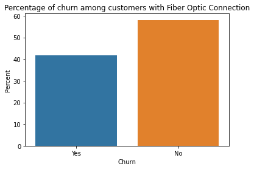

```python
ax = sns.barplot(x="Churn", y="TotalCharges", data=data[data['InternetService']=='Fiber optic'],
                 estimator=lambda x: len(x) / len(data[data['InternetService']=='Fiber optic']) * 100)
ax.set(ylabel="Percent")
ax.set_title('Percentage of churn among customers with Fiber Optic Connection')
```

**Obsrvations:** As we can see a whopping 40% of customers with Fiber Optic connection has churned

## Breakdown of Churn among customers who has availed additional services

```
[Text(0, 0.5, 'Existing Customers'),
```

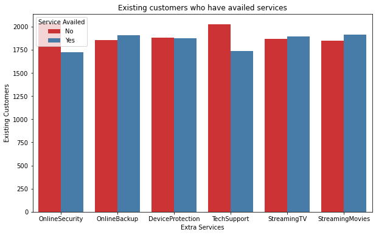

```python
addc = ["OnlineSecurity", "OnlineBackup", "DeviceProtection", "TechSupport", "StreamingTV", "StreamingMovies"]
addl = pd.melt(data[(data["InternetService"]!="No") & (data['Churn']=='No')][addc]).rename({'value': 'Service Availed'}, axis=1)
plt.figure(figsize=(10, 6))
ax = sns.countplot(data=addl, x='variable', hue='Service Availed', palette='Set1')
ax.set(xlabel='Extra Services', ylabel='Existing Customers', title='Existing customers who have availed services')
```

```
[Text(0, 0.5, 'Number of Churners'),
```

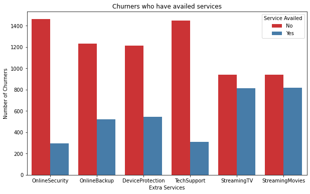

```python
plt.figure(figsize=(10, 6))

addlc = pd.melt(data[(data["InternetService"]!="No") & (data['Churn']=='Yes')][addc]).rename({'value': 'Service Availed'}, axis=1)
ax = sns.countplot(data=addlc, x='variable', hue='Service Availed', hue_order=['No', 'Yes'], palette='Set1')
ax.set(xlabel='Extra Services', ylabel='Number of Churners', title='Churners who have availed services')
```

**Obsrvations:**

1. A lot of customers who have availed the streaming services have churned.
2. The other extra services seem to be a gppd predictor of churn

## Box plot of type of contract

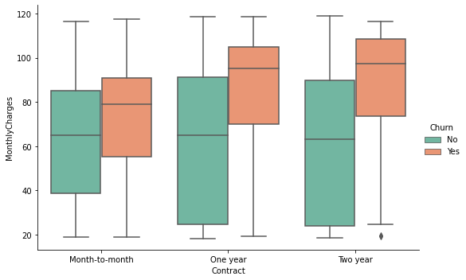

```python
sns.catplot(x="Contract", y="MonthlyCharges", hue="Churn", kind="box", data=data, height=5, aspect=1.5, palette='Set2')
```

**Obsrvations:** Predictably month to month contract holders tend to churn more

## Box plot of payment methods

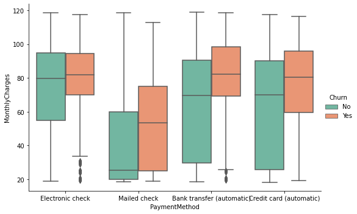

```python
sns.catplot(x="PaymentMethod", y="MonthlyCharges", hue="Churn", kind="box", data=data, height=5, aspect=1.5, palette='Set2')
```

**Observations:** There seems to be a good vairance of churners among the different payment methods

## Data Cleaning

All the categorical features are one hot encoded. The 'No' column of binary features are droppped.

```python
del data['customerID']
data = pd.get_dummies(data)
drop = ['Churn_No', 'gender_Female', 'Partner_No', 'Dependents_No', 'PhoneService_No', 'PaperlessBilling_No']
data = data.drop(drop,axis=1)

y = data.iloc[:,40]
del data['Churn_Yes']
X = data
```

## Feature Importance

Random forest classifier is used to find the feature importances. The feature with less than the median imprtance are dropped

```python
from sklearn.ensemble import RandomForestClassifier
from sklearn.feature_selection import SelectFromModel
from sklearn.model_selection import StratifiedKFold

classr = RandomForestClassifier(n_estimators=5000, n_jobs=4, max_depth=8)
classr = classr.fit(X, y)

features = pd.DataFrame()
features['features'] = X.columns
features['importance'] = classr.feature_importances_
sortf = features.sort_values(by = ['importance'], ascending = False)
```

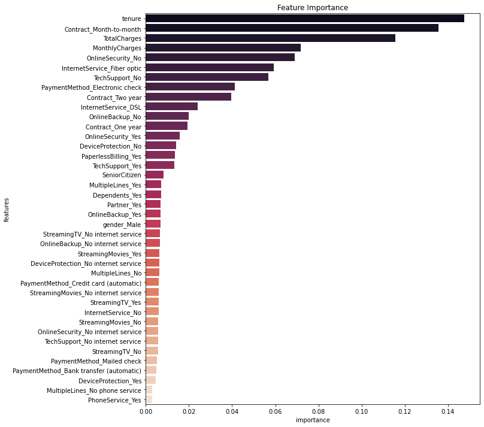

```python
plt.figure(figsize=(10,12))
plt.title("Feature Importance")
ax = sns.barplot(x='importance', y='features', data=sortf, palette="rocket", orient='h')
```

```python
select_feat = SelectFromModel(classr, threshold = 'median', prefit = True)
X = select_feat.transform(X)
```

```python
from sklearn.model_selection import train_test_split
X_train, X_test, y_train, y_test = train_test_split(X, y, test_size = 0.3, random_state = 0)
```

## Modeling

Grid Search is used to find the best hyperparameters for the random forest classifier:

```python
from sklearn.model_selection import GridSearchCV

params = {
        'n_estimators' : [50, 40, 30],
        'criterion' : ['entropy', 'gini'],
        'max_features' : ['sqrt', 'log2', None],
        'max_depth' : [8, 9, 10]
          }

crv = StratifiedKFold(n_splits = 5)
grids = GridSearchCV(classr, params, scoring = 'accuracy', cv = crv, n_jobs = -1)
grids = grids.fit(X_train, y_train)
```

[output not shown]

```python
classr2 = RandomForestClassifier(n_estimators = 40, criterion = 'entropy', max_features = 'log2',
                                 max_depth = 8)
classr2 = classr2.fit(X_train, y_train)

y_pred = classr2.predict(X_test)

from sklearn.metrics import confusion_matrix, classification_report, accuracy_score
cm = confusion_matrix(y_test, y_pred)
```

```python
from sklearn.metrics import classification_report, accuracy_score, roc_curve, auc
```

```python
probs = classr2.predict_proba(X_test)
```

## ROC Curve

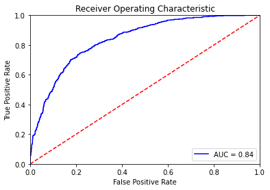

```python
pred = probs[:,1]
fpr, tpr, threshold = roc_curve(y_test, pred)
roc_auc = auc(fpr, tpr)


plt.title('Receiver Operating Characteristic')
plt.plot(fpr, tpr, 'b', label = 'AUC = %0.2f' % roc_auc)
plt.legend(loc = 'lower right')
plt.plot([0, 1], [0, 1],'r--')
plt.xlim([0, 1])
plt.ylim([0, 1])
plt.ylabel('True Positive Rate')
plt.xlabel('False Positive Rate')
plt.show()
```

```python
from sklearn.model_selection import cross_val_score
crossval = cross_val_score(classr2, X_train, y = y_train, cv = 10)
```